# Universidade de Brasília IE - Departamento de Estatística Análise de Dados Categorizados - 1/2025

# Lista de Exercícios Ia

Estude o tópico 1.1 do capítulo 1 do livro-texto e as notas de aula e resolva os seguintes exercícios:

**1. Em cada caso apresentado a seguir, identifique a variável resposta e as variáveis explicativas. Classifique também todas as variáveis quanto ao tipo (qualitativa - nominal ou ordinal, quantitativa - discreta ou contínua):**

1. Atitude em relação ao controle de armas (a favor, contra), gênero (feminino, masculino), educação da mãe (ensino médio, nível superior).

Qualitativa nominal, qualitativa Nominal, qualitativa ordinal

2. Doença cardíaca (sim, não), pressão arterial, nível de colesterol.

Qualitativa nominal, quantitativa continua, quantitativa continua

3. Raça (branca, não branca), religião (católica, judaica, muçulmana, protestante, nenhuma), voto para presidente (democrata, republicano, outro), renda anual.

Qualitativa nominal, qualitativa nominal, qualitativa nominal, qualitativa ordinal (imagino que seja em salarios minimos)

4. Alívio da dor de dente (0, 1, 2, 3, 4 horas), dosagem do medicamento (10, 20, 30 mg) e idade (<20, 20–40 anos, 40–60 anos, ≥60 anos).

Qualitativa ordinal, qualitativa ordinal, qualitativa ordinal

5. Método de aprendizado preferido (individual, em grupo, em sala de aula) e período escolar frequentado (padrão, integral).

Qualitativa nominal, qualitativa nominal

**2. Qual escala de mensuração é mais apropriada para as seguintes variáveis - nominal ou ordinal?**

1. Preferência de partido político do Reino Unido (Trabalhista, Liberal Democrata, Conservador, outro).

Nominal

2. Maior grau educacional obtido (nenhum, ensino fundamental, ensino médio, graduação, mestrado, doutorado).

Ordinal

3. Estado do paciente (bom, regular, grave, crítico).

Ordinal (apesar de que faz sentido ser nominal tambem)

4. Localização do hospital (Londres, Boston, Madison, Rochester, Toronto).

Nominal

5. Bebida preferida (cerveja, suco, leite, refrigerante, vinho, outra).

Nominal

6. Classificação de um filme com 1 a 5 estrelas, representando (odiei, não gostei, gostei, gostei muito, adorei).

Ordinal

> *Exercícios 1 e 2 da 2ª edição do livro-texto (2007) adaptados.*

# Explorando Dados (descritivamente…)

Em cada um dos exercícios a seguir:  
- identifique as variáveis estudadas e classifique-as quanto ao tipo;  
- identifique a variável resposta e a variável explicativa;  
- analise os dados (sugestão: utilizando frequências relativas adequadas e representação gráfica apropriada);  
- elabore pelo menos um parágrafo com a análise dos dados indicando se eles sugerem alguma associação entre as características estudadas.

**3. Considere as distribuições do tipo de combustível doméstico usado em duas cidades, em 2023:**

$$\begin{array}{l|cc}
\hline
\textbf{Tipo de combustível} & \textbf{Cidade A} &
\textbf{Cidade B} \\
\hline
Gás & 67.450 & 31800 \\
Eletricidade & 23.800 & 3.450 \\
Outros & 6.450 & 3.850 \\
\hline
\textbf{TOTAL} & 97.700 & 39.100 \\
\hline
\end{array}$$

1. Identifique a população estudada.

A população estudada são todas as residências das duas cidades em 2023 que utilizam algum tipo de combustível.

2. Qual o objetivo do estudo?

O objetivo é comparar a distribuição do tipo de combustível doméstico utilizado nas residências das duas cidades em 2023, observando as diferenças relativas no uso.

3. Identifique as variáveis estudadas e classifique-as.

Tipo de combustível: qualitativa nominal.

Cidade: qualitativa nominal.

Valores do tipo de combustivel: Quantitativa Discreta

4. Construa um gráfico adequado para comparar simultaneamente as distribuições do tipo de combustível das duas cidades e comente brevemente.

```r
# 1. Dados corrigidos
combustivel <- data.frame(
  Tipo         = c("Gás", "Eletricidade", "Outros"),
  Cidade_A     = c(67450, 23800, 6450),
  Cidade_B     = c(31800,  3450, 3850),
  stringsAsFactors = FALSE
)

# 2. Calcular totais
totais <- colSums(combustivel[, c("Cidade_A","Cidade_B")])

# 3. Frequências relativas (percentual)
rel <- prop.table(as.matrix(combustivel[, c("Cidade_A","Cidade_B")]), margin = 2) * 100

# 4. Formatar tabela como data.frame legível
rel_df <- data.frame(
  Tipo = combustivel$Tipo,
  `Cidade A (%)` = sprintf("%.1f%%", rel[, "Cidade_A"]),
  `Cidade B (%)` = sprintf("%.1f%%", rel[, "Cidade_B"]),
  check.names = FALSE,
  stringsAsFactors = FALSE
)

# 5. Exibir tabela formatada
print(rel_df)
```

```
##           Tipo Cidade A (%) Cidade B (%)
## 1          Gás        69.0%        81.3%
## 2 Eletricidade        24.4%         8.8%
## 3       Outros         6.6%         9.8%
```

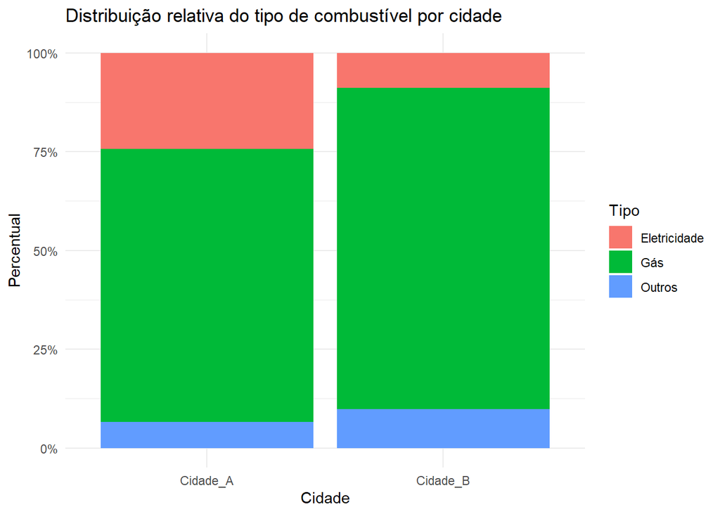

```r
# 6. Gráfico comparativo
library(ggplot2)
library(tidyr)

comb_long <- pivot_longer(
  combustivel,
  cols = c("Cidade_A","Cidade_B"),
  names_to = "Cidade",
  values_to = "Frequencia"
)

ggplot(comb_long, aes(x = Cidade, y = Frequencia, fill = Tipo)) +
  geom_bar(stat = "identity", position = "fill") +
  scale_y_continuous(labels = scales::percent_format(accuracy = 1)) +
  labs(
    title = "Distribuição relativa do tipo de combustível por cidade",
    x = "Cidade", y = "Percentual"
  ) +
  theme_minimal()
```

5. Justifique a proposição: *“De forma relativa, a cidade B usa mais gás que a cidade A.”*

O gráfico de barras empilhadas padronizadas evidencia essa diferença, a Cidade B depende proporcionalmente muito mais de gás do que a Cidade A

6. Analise os dados (elabore pelo menos um parágrafo com sua análise).

**4. Uma amostra de 200 habitantes de uma cidade foi coletada para analisar a atitude frente a um certo projeto governamental. O resultado foi o seguinte:**

$$\begin{array}{l|ccc|c}
\hline
\textbf{Opinião} & \textbf{Urbana} & \textbf{Suburbana} &
\textbf{Rural} & \textbf{Total} \\
\hline
A favor & 30 & 35 &
35 & 100 \\
Contra & 60 & 25 &
15 & 100 \\
\hline
\textbf{Total} & 90 & 60 &
50 & 200 \\
\hline
\end{array}$$

1. Identifique a população estudada.

A população estudada são os habitantes da cidade em que se coletou a amostra

2. Qual o objetivo do estudo?

O objetivo é avaliar se há diferença na opinião em relação a um projeto governamental entre os diferentes locais de residência.

3. Identifique as variáveis estudadas e classifique-as.

Opinião: qualitativa nominal.

Local de residência: qualitativa nominal.

4. Calcule as proporções em relação ao total das colunas. Justifique a determinação destas medidas em vez de proporções em relação ao total das linhas.

```r
# Dados
opiniao <- matrix(
  c(30, 60,   # Urbana: A favor, Contra
    35, 25,   # Suburbana
    35, 15),  # Rural
  nrow = 2, byrow = FALSE,
  dimnames = list(
    Opiniao = c("A favor", "Contra"),
    Local   = c("Urbana", "Suburbana", "Rural")
  )
)

# Proporções por coluna (total de cada local)
prop_col <- prop.table(opiniao, margin = 2) * 100

# Formatar com símbolo de porcentagem
prop_col_fmt <- apply(prop_col, c(1,2), function(x) sprintf("%.1f%%", x))

# Exibir tabela formatada
as.data.frame.matrix(prop_col_fmt)
```

```
##         Urbana Suburbana Rural
## A favor  33.3%     58.3% 70.0%
## Contra   66.7%     41.7% 30.0%
```

5. Represente graficamente os dados.

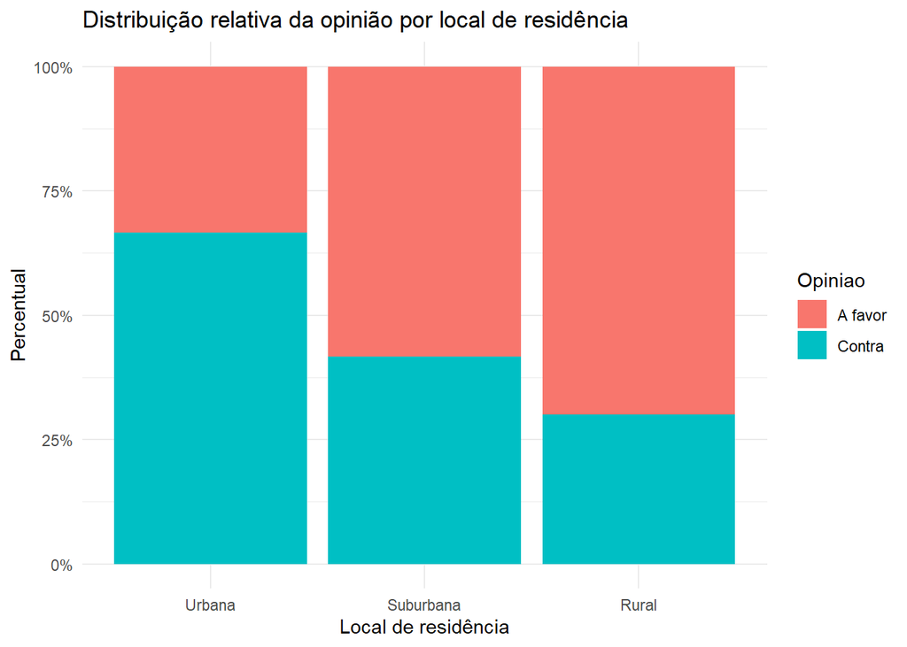

```r
# Converter em data frame longo
opiniao_df <- as.data.frame(as.table(opiniao))
colnames(opiniao_df) <- c("Opiniao", "Local", "Frequencia")

# Gráfico
ggplot(opiniao_df, aes(x = Local, y = Frequencia, fill = Opiniao)) +
  geom_bar(stat = "identity", position = "fill") +
  scale_y_continuous(labels = scales::percent_format(accuracy = 1)) +
  labs(
    title = "Distribuição relativa da opinião por local de residência",
    x = "Local de residência",
    y = "Percentual"
  ) +
  theme_minimal()
```

6. Com base nos resultados obtidos no item **d**, você diria que a opinião independe do local de residência?

Observando as proporções, a zona urbana tem 66,7% (Contra) e apenas 33,3% (A favor), enquanto as zonas suburbana e rural têm maioria (A favor) (58,3% e 70%, respectivamente). Esses contrastes sugerem que há diferença clara de opinião entre os locais.

7. O gráfico construído no item **e** sinaliza o mesmo que você concluiu no item **f**?

8. Analise os dados (elabore pelo menos um parágrafo com sua análise).

A análise das proporções por local de residência mostra que apenas 33,3% dos moradores urbanos são a favor do projeto, ao passo que 58,3% dos suburbanos e 70,0% dos rurais apoiam. Essa variação indica uma forte associação entre opinião e local de residência.